# Full and restricted model. Simulations

Piotr Król

26 07 2021

Content:

- Model on full pool (670 items)
  - Items fit
  - Local dependence
  - Simulation 100 random items
  - Simulation 50 random items
  - Simulation max 50 items, SE = .15
  - Simulation with Kachergis’ specification (adds also min 25 items)
- Model on restricted pool (200 items)
  - Items selection
  - Model creation
  - Items fit
  - Local dependence
  - Simulation with Kachergis settings
- Model on restricted pool (the lowest RMSEA)
  - Simulation with Kachergis settings (298 items)

```r
library(mirt)
library(mirtCAT)
library(parallel)
library(ggpubr)
library(plyr)
library(CTT)
```

# Model on full pool (670 items)

Take model with 601 quadratures:

```r
mod
```

```
##
## Call:
## mirt(data = responses, model = 1, SE = TRUE, quadpts = 601, technical = list(NCYCLES = 10000))
##
## Full-information item factor analysis with 1 factor(s).
## Converged within 1e-04 tolerance after 2652 EM iterations.
## mirt version: 1.34
## M-step optimizer: BFGS
## EM acceleration: Ramsay
## Number of rectangular quadrature: 601
## Latent density type: Gaussian
##
## Information matrix estimated with method: Oakes
## Second-order test: model is a possible local maximum
## Condition number of information matrix =  2310.672
##
## Log-likelihood = -462860.7
## Estimated parameters: 1340
## AIC = 928401.3; AICc = 932160.6
## BIC = 936092.1; SABIC = 931834.6
## G2 (9999998660) = 890631.4, p = 1
## RMSEA = 0, CFI = NaN, TLI = NaN
```

## Items fit

```r
itemfit <- itemfit(mod, method = "MAP") #Use default S_X2 statistic and MAP ability estimation
```

```r
head(itemfit)
```

[output not shown]

Number of misfits before correction (for p = 0.1):

```r
length(which(itemfit$p.S_X2 < 0.1))
```

```
## [1] 79
```

Number of misfits after correction:

```r
itemfit$p.S_X2_fdr <- p.adjust(itemfit$p.S_X2, 'fdr')
length(which(itemfit$p.S_X2_fdr < 0.1))
```

```
## [1] 0
```

Check histogram of p-values:

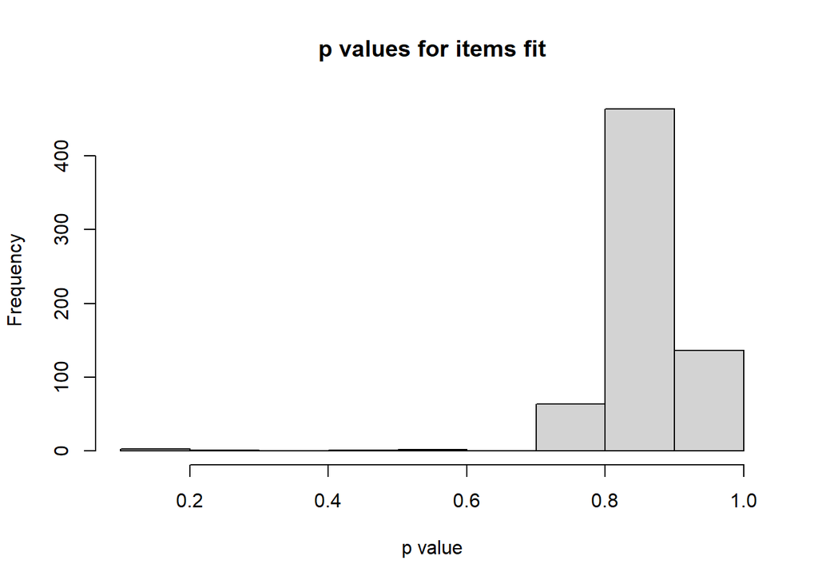

```r
hist(itemfit$p.S_X2_fdr, main = "p values for items fit", xlab = "p value")
```

```r
length(which(itemfit$p.S_X2_fdr < 0.3))
```

```
## [1] 4
```

Check RMSEA values used which helps gauge the magnitude of item misfit:

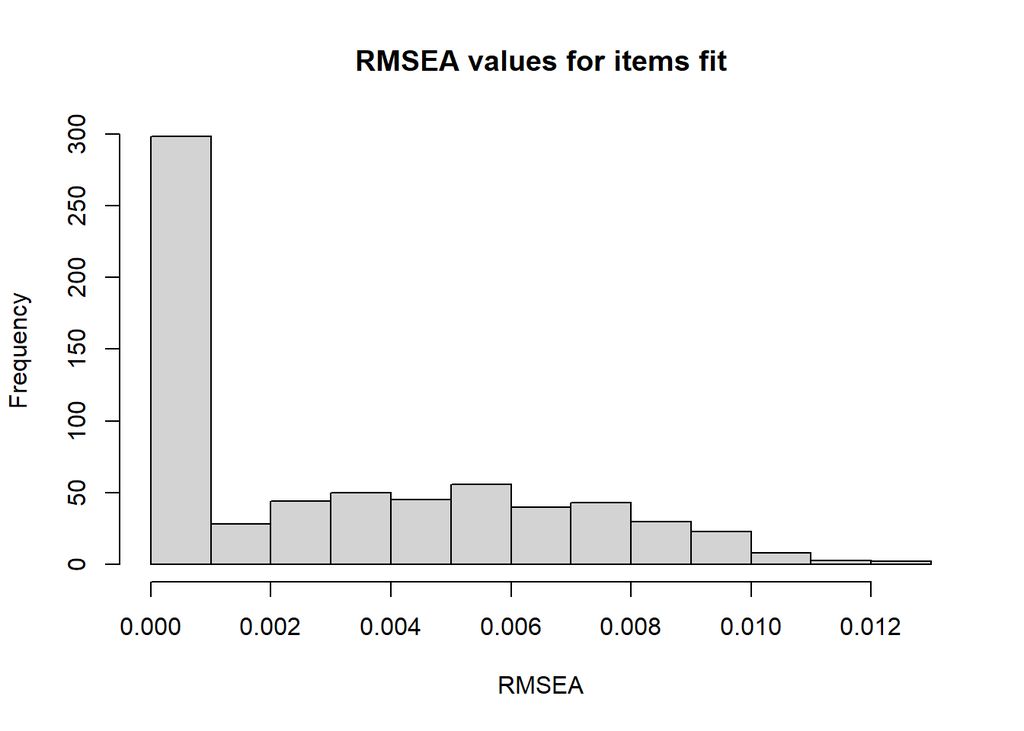

```r
hist(itemfit$RMSEA.S_X2, main = "RMSEA values for items fit", xlab = "RMSEA")
```

Check how many items have RMSEA higher than 0.01:

```r
length(which(itemfit$RMSEA.S_X2 > 0.01))
```

```
## [1] 13
```

Check p-values of those items:

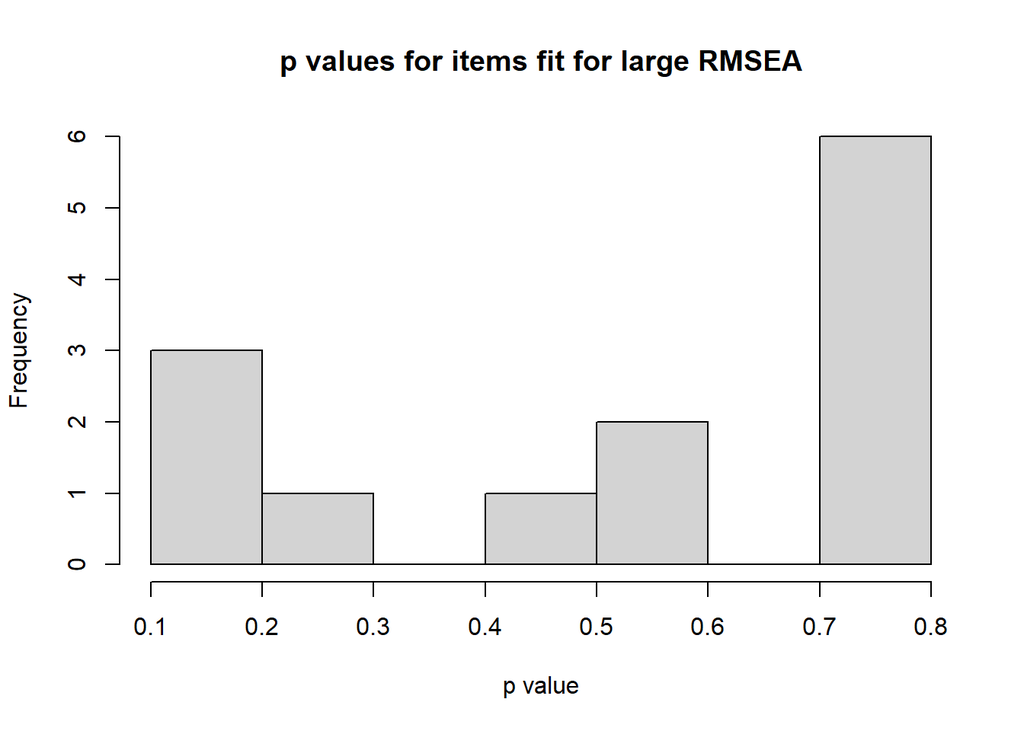

```r
hist(itemfit[itemfit$RMSEA.S_X2 > 0.01, ]$p.S_X2_fdr, main = "p values for items fit for large RMSEA", xlab = "p value")
```

Check what items have both RMSEA > 0.01 and p < 0.3:

```r
itemfit[itemfit$RMSEA.S_X2 > 0.01 & itemfit$p.S_X2_fdr < 0.3, ]
```

```
##        item    S_X2 df.S_X2 RMSEA.S_X2 p.S_X2 p.S_X2_fdr
## 392 item392 337.266     253      0.012  0.000      0.132
## 417 item417 293.811     222      0.012  0.001      0.196
## 463 item463 359.082     284      0.011  0.002      0.278
## 652 item652 422.019     329      0.011  0.000      0.132
```

```r
cdi[row.names(itemfit[itemfit$RMSEA.S_X2 > 0.01 & itemfit$p.S_X2_fdr < 0.3, ]), ]
```

```
##             category number.ws number.wg  position
## 392 Z14.przymiotniki       392       264    gorący
## 417   Z15.przysłówki       417       264    gorąco
## 463   Z16.czasowniki       463       304 mieć..ma.
## 652     Z24.przyimki       652        NA         o
```

## Local dependence

```r
residuals <- residuals(mod)
```

Check signed Cramers V coefficients:

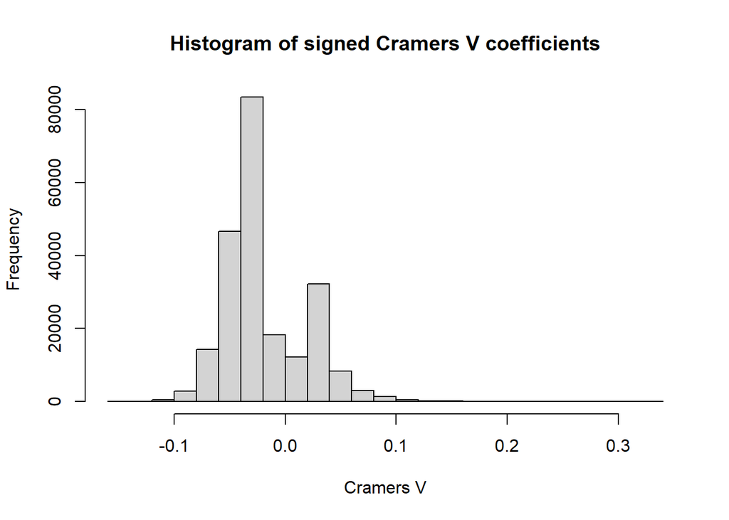

```r
hist(residuals[upper.tri(residuals)], main="Histogram of signed Cramers V coefficients", xlab= "Cramers V")
```

So there are no items even close to Kachergis’ Cramer’s V = 0.5

## Simulations full pool

```r
fscores <- fscores(mod, method = "MAP")
params <- as.data.frame(coef(mod, simplify = TRUE)$items)[1:2]
mo <- generate.mirt_object(params, '2PL')
cl <- makeCluster(detectCores()) #Speeds up simulations (many in paralell)
```

### 100 random items

```r
sim_results_100 <- mirtCAT(mo = mo, method = "MAP", criteria = "random", start_item = "random", local_pattern = responses, cl = cl, design = list(min_items = 100, max_items = 100))
```

#### Correlations

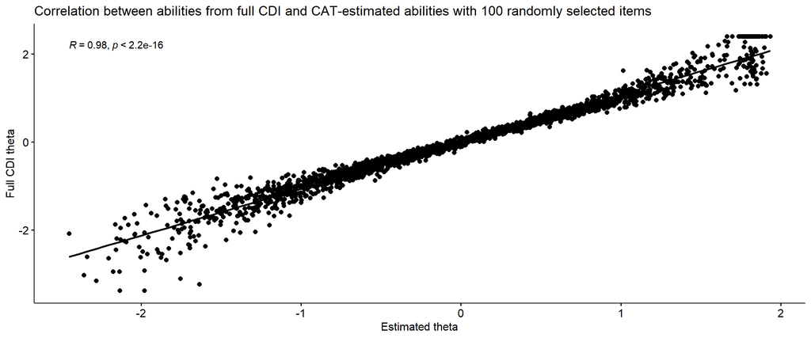

```r
sim_results <- sim_results_100
thetas <- laply(sim_results, function(x) x$thetas)
ggscatter(data.frame(est = thetas, full = as.numeric(fscores)), x = "est", y = "full",
                  add = "reg.line", conf.int = TRUE,
                  cor.coef = TRUE, cor.method = "pearson",
                  xlab = "Estimated theta", ylab = "Full CDI theta", title = "Correlation between abilities from full CDI and CAT-estimated abilities with 100 randomly selected items")
```

```r
cor(thetas, as.numeric(fscores))
```

```
## [1] 0.9840703
```

In Kachergis it was 0.985 for English production.

#### SE

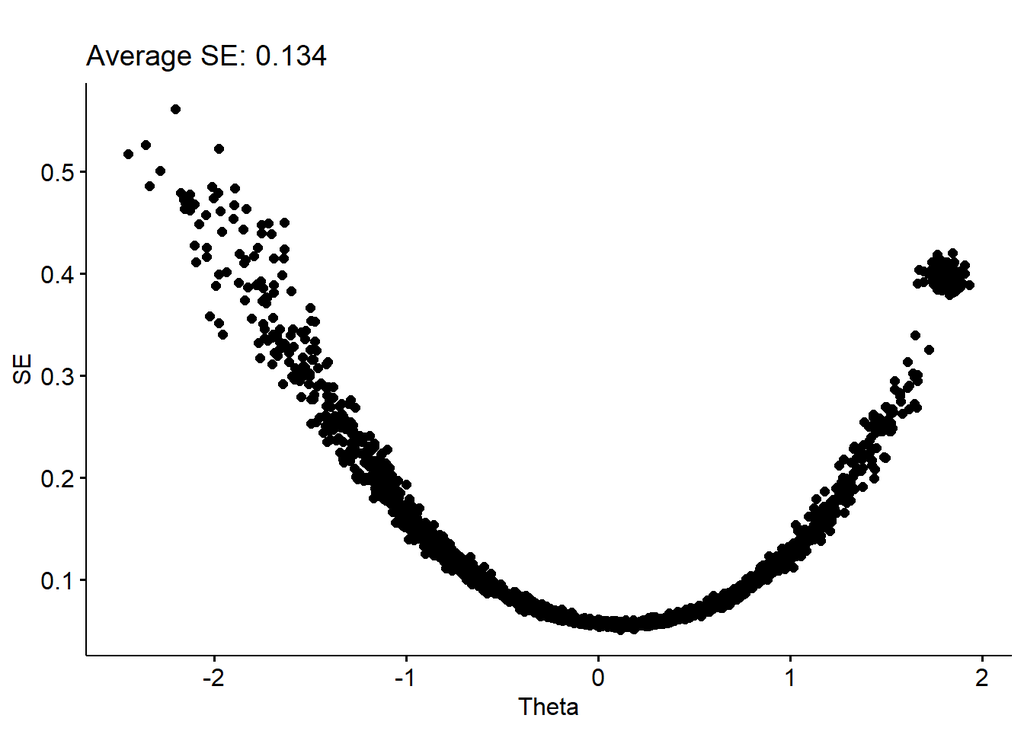

```r
SEthetas <- laply(sim_results, function(x) x$SE_thetas)
ggscatter(data.frame(est = thetas, SE = SEthetas), y = "SE", x = "est",
                  xlab = "Theta", ylab = "SE", title = paste0("\nAverage SE: ", round(mean(SEthetas),3)))
```

In Kachergis it was 0.188 for English production. Do we have model with better fit?

### 50 random items

```r
cl <- makeCluster(detectCores())
sim_results_50 <- mirtCAT(mo = mo, method = "MAP", criteria = "random", start_item = "random", local_pattern = responses, cl = cl, design = list(min_items = 50, max_items = 50))
```

#### Correlation

```r
sim_results <- sim_results_50
thetas <- laply(sim_results, function(x) x$thetas)
cor(thetas, as.numeric(fscores))
```

```
## [1] 0.9713625
```

In Kachergis it was also 0.971

#### Average SE

```r
SEthetas <- laply(sim_results, function(x) x$SE_thetas)
round(mean(SEthetas),3)
```

```
## [1] 0.177
```

In Kachergis it was 0.242

### max 50 items, SE = 0.15, MI item selection

```r
cl <- makeCluster(detectCores())
sim_results_qk <- mirtCAT(mo = mo, method = "MAP", criteria = "MI", start_item = "MI", local_pattern = responses, cl = cl, design = list(min_SEM = 0.15, max_items = 50))
```

#### Correlation

```r
sim_results <- sim_results_qk
thetas <- laply(sim_results, function(x) x$thetas)
cor(thetas, as.numeric(fscores))
```

```
## [1] 0.9756431
```

#### Average SE

```r
SEthetas <- laply(sim_results, function(x) x$SE_thetas)
round(mean(SEthetas),3)
```

```
## [1] 0.161
```

#### Mean number of items

```r
items_answered <- laply(sim_results, function(x) length(x$items_answered))
round(mean(items_answered), 1)
```

```
## [1] 18.1
```

#### Unused items

```r
#Prepare df with frequencies of usage of items
frequency_df <- data.frame(number.ws = c(1:nrow(params)), freq = rep(0, nrow(params)))

#Update df with number of occurence of given item
for (p in 1:length(sim_results)){
  items <- sim_results[[p]]$items_answered
  for (number.ws in items){
    frequency_df[frequency_df["number.ws"] == number.ws, "freq"] <- frequency_df[frequency_df["number.ws"] == number.ws, "freq"] + 1
  }
}

length(which(frequency_df$freq == 0))
```

```
## [1] 509
```

### Kachergis specification: min 25 items, max 50 items, SE = 0.15

```r
cl <- makeCluster(detectCores())
sim_results_k <- mirtCAT(mo = mo, method = "MAP", criteria = "MI", start_item = "MI", local_pattern = responses, cl = cl, design = list(min_SEM = 0.15, min_items = 25, max_items = 50))
```

#### Correlation

```r
sim_results <- sim_results_k
thetas <- laply(sim_results, function(x) x$thetas)
cor(thetas, as.numeric(fscores))
```

[output not shown]

In Kachergis it was 0.993 (for English production)

#### Average SE

```r
SEthetas <- laply(sim_results, function(x) x$SE_thetas)
round(mean(SEthetas),3)
```

[output not shown]

In Kachergis it was 0.136

#### Mean number of items

```r
items_answered <- laply(sim_results, function(x) length(x$items_answered))
round(mean(items_answered), 1)
```

[output not shown]

In Kachergis it was 39.5 (we can have on average 10 items shorter tests?)

#### Unused items

Prepare frequency table:

```r
#Prepare df with frequencies of usage of items
frequency_df <- data.frame(number.ws = c(1:nrow(params)), freq = rep(0, nrow(params)))

#Update df with number of occurence of given item
for (p in 1:length(sim_results)){
  items <- sim_results[[p]]$items_answered
  for (number.ws in items){
    frequency_df[frequency_df["number.ws"] == number.ws, "freq"] <- frequency_df[frequency_df["number.ws"] == number.ws, "freq"] + 1
  }
}

length(which(frequency_df$freq == 0))
```

[output not shown]

In Kachergis it was 405

# Model on restricted pool (200 items)

## Items selection

Calculate CTT parameters and distance from (0,0)

```r
cors <- apply(responses, 2, FUN = function(x) cor(x, responses_demo$months))
ctt_analysis <- itemAnalysis(responses)
ctt_params <- data.frame(dffclt = ctt_analysis$itemReport$itemMean, dscrmn = ctt_analysis$itemReport$pBis, cors = cors)
ctt_params$dist <- sqrt(ctt_params$dscrmn^2 + ctt_params$cors^2)
ctt_params <- cbind(ctt_params, cdi)
```

Colour by difficulties:

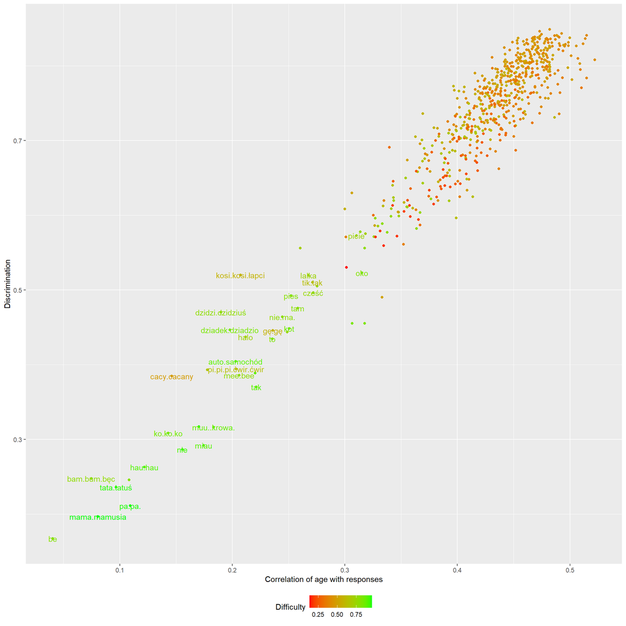

```r
ggplot(ctt_params, aes(cors, dscrmn, label=position, colour=dffclt)) +
  geom_point() +
  xlab("Correlation of age with responses") +
  ylab("Discrimination") +
  geom_text(aes(label=ifelse(dscrmn < 0.6 & cors < 0.35, as.character(position),'')), check_overlap = T) +
  theme(legend.position = "bottom") +
  scale_color_gradient(low="red", high="green") +
  labs(colour = "Difficulty")
```

Select best 200 items:

```r
ctt_params_s <- ctt_params[order(ctt_params$dist, decreasing = T), ][1:200, ]
ctt_params[ctt_params$number.ws %in% ctt_params_s$number.ws, "best200"] <- TRUE
ctt_params[is.na(ctt_params$best200), "best200"] <- FALSE
```

Visualize it:

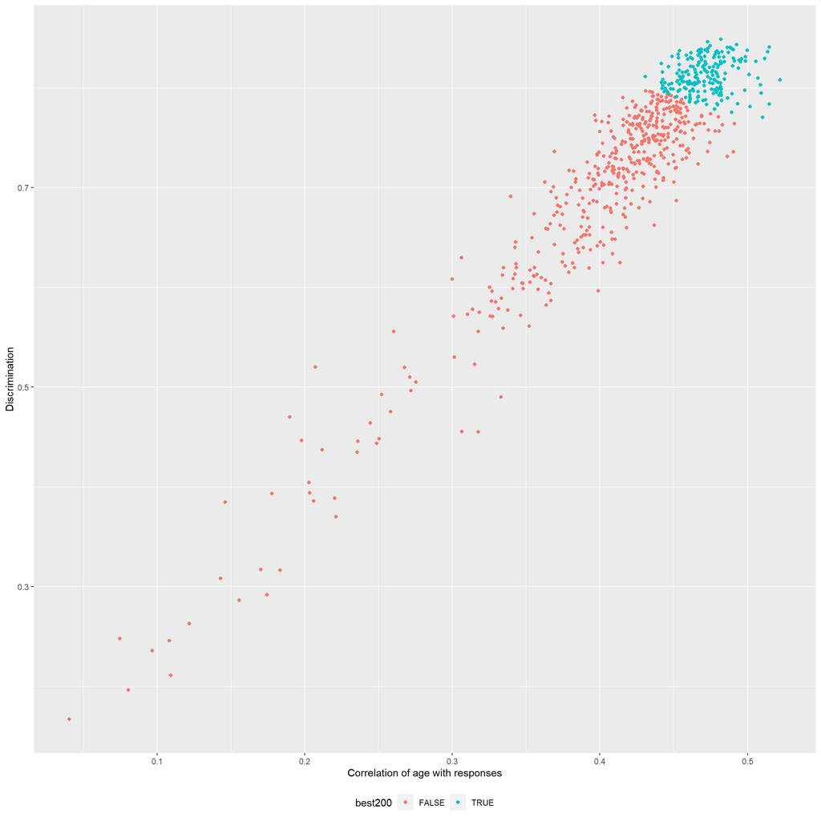

```r
ggplot(ctt_params, aes(cors, dscrmn, colour=best200)) +
  geom_point() +
  xlab("Correlation of age with responses") +
  ylab("Discrimination") +
  theme(legend.position = "bottom") +
  labs(colour = "best200")
```

## Model creation

```r
mod_restr <- mirt(data = responses[, row.names(ctt_params_s)], model = 1, SE = TRUE)
```

```r
mod_restr
```

```
##
## Call:
## mirt(data = responses[, row.names(ctt_params_s)], model = 1,
##     SE = TRUE)
##
## Full-information item factor analysis with 1 factor(s).
## Converged within 1e-04 tolerance after 289 EM iterations.
## mirt version: 1.34
## M-step optimizer: BFGS
## EM acceleration: Ramsay
## Number of rectangular quadrature: 61
## Latent density type: Gaussian
##
## Information matrix estimated with method: Oakes
## Second-order test: model is a possible local maximum
## Condition number of information matrix =  139.4927
##
## Log-likelihood = -117555.4
## Estimated parameters: 400
## AIC = 235910.8; AICc = 236080
## BIC = 238206.5; SABIC = 236935.7
## G2 (1e+10) = 205225.8, p = 1
## RMSEA = 0, CFI = NaN, TLI = NaN
```

Check if increasing number of quadratures changes something:

```r
mod_restr2 <- mirt(data = responses[, row.names(ctt_params_s)], model = 1, SE = TRUE, quadtps = 101)
```

```r
mod_restr2
```

```
##
## Call:
## mirt(data = responses[, row.names(ctt_params_s)], model = 1,
##     SE = TRUE, quadtps = 101)
##
## Full-information item factor analysis with 1 factor(s).
## Converged within 1e-04 tolerance after 289 EM iterations.
## mirt version: 1.34
## M-step optimizer: BFGS
## EM acceleration: Ramsay
## Number of rectangular quadrature: 61
## Latent density type: Gaussian
##
## Information matrix estimated with method: Oakes
## Second-order test: model is a possible local maximum
## Condition number of information matrix =  139.4927
##
## Log-likelihood = -117555.4
## Estimated parameters: 400
## AIC = 235910.8; AICc = 236080
## BIC = 238206.5; SABIC = 236935.7
## G2 (1e+10) = 205225.8, p = 1
## RMSEA = 0, CFI = NaN, TLI = NaN
```

## Items fit

```r
itemfit_r <- itemfit(mod_restr, method = "MAP") #Use default S_X2 statistic and MAP ability estimation
```

Number of misfits before correction (for p = 0.1):

```r
length(which(itemfit_r$p.S_X2 < 0.1))
```

```
## [1] 29
```

Number of misfits after correction:

```r
itemfit_r$p.S_X2_fdr <- p.adjust(itemfit_r$p.S_X2, 'fdr')
length(which(itemfit_r$p.S_X2_fdr < 0.1))
```

```
## [1] 2
```

Check histogram of p-values:

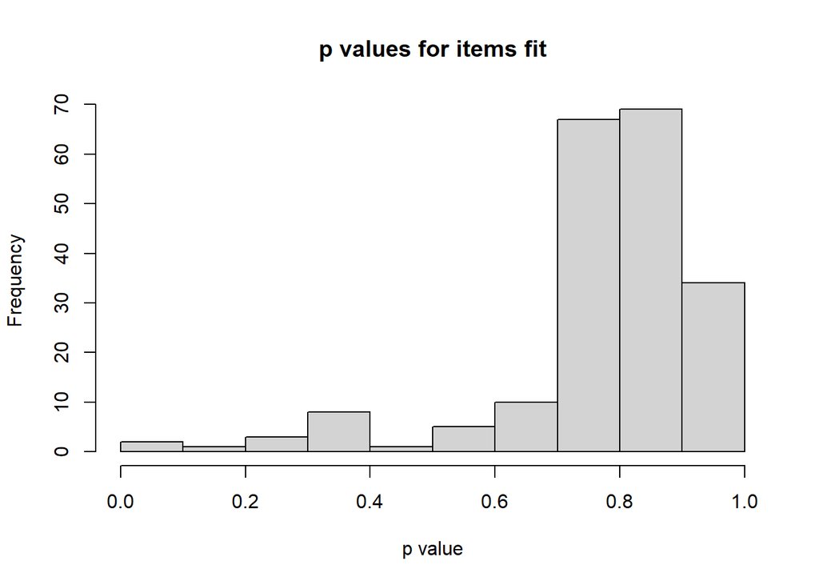

```r
hist(itemfit_r$p.S_X2_fdr, main = "p values for items fit", xlab = "p value")
```

Check RSMEA values:

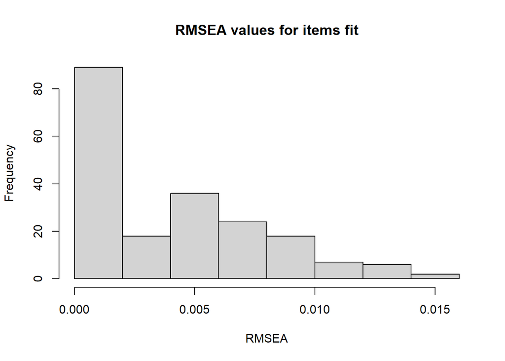

```r
hist(itemfit_r$RMSEA.S_X2, main = "RMSEA values for items fit", xlab = "RMSEA")
```

```r
itemfit_r[itemfit_r$RMSEA.S_X2 > 0.012 | itemfit_r$p.S_X2_fdr < 0.2, ]
```

```
##        item    S_X2 df.S_X2 RMSEA.S_X2 p.S_X2 p.S_X2_fdr
## 1   item537 145.012     106      0.013  0.007      0.237
## 34  item539 122.378      91      0.012  0.016      0.346
## 131 item506 210.045     141      0.015  0.000      0.026
## 133 item540 147.240     106      0.013  0.005      0.235
## 146 item511 179.954     135      0.012  0.006      0.235
## 158 item248 192.946     141      0.013  0.002      0.161
## 176 item478 211.555     145      0.014  0.000      0.026
## 180 item502 127.137      95      0.012  0.015      0.346
```

```r
cdi[row.names(itemfit_r[itemfit_r$RMSEA.S_X2 > 0.012 | itemfit_r$p.S_X2_fdr < 0.2, ]), ]
```

```
##             category number.ws number.wg   position
## 1        Z01.odgłosy         1         1      gę.gę
## 34     Z02.zwierzęta        34        NA     mrówka
## 131      Z04.pokarmy       131        NA  truskawki
## 133      Z04.pokarmy       133        84       woda
## 146      Z05.zabawki       146        NA    obrazek
## 158      Z06.ubrania       158       100      guzik
## 176      Z06.ubrania       176       116 śliniaczek
## 180 Z07.części_ciała       180       120      buzia
```

So truskawki and śliniaczek should be probably removed. These are different items than earlier.

## Local dependence

```r
residuals_r <- residuals(mod_restr)
```

Check signed Cramers V coefficients:

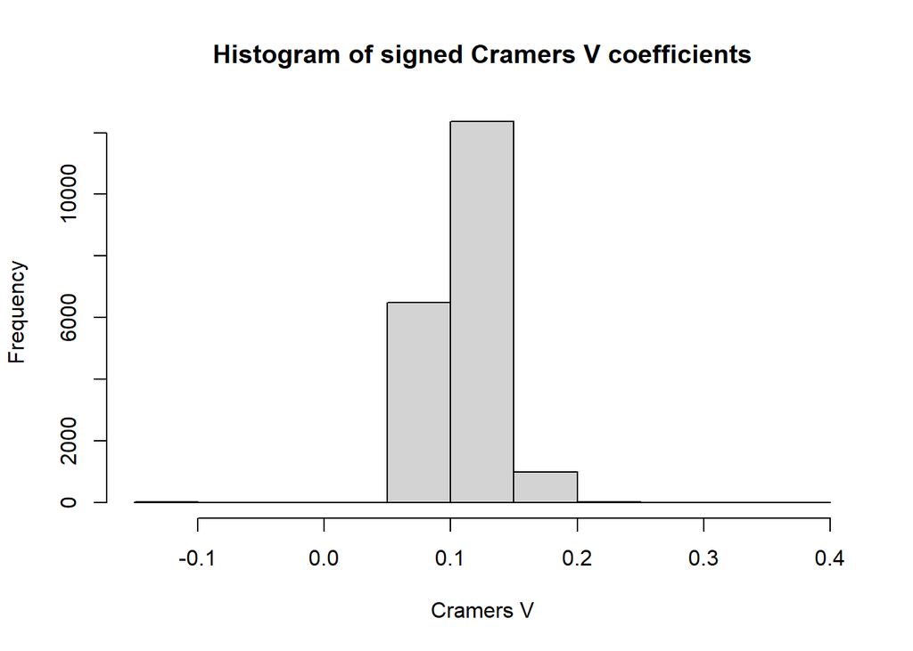

```r
hist(residuals_r[upper.tri(residuals_r)], main="Histogram of signed Cramers V coefficients", xlab= "Cramers V")
```

Again, no high Cramers Vs

## Simulation with Kachergis setting

```r
fscores_r <- fscores(mod_restr, method = "MAP")
params_r <- as.data.frame(coef(mod_restr, simplify = TRUE)$items)[1:2]
mo_r <- generate.mirt_object(params_r, '2PL')
cl <- makeCluster(detectCores())
sim_results_k_r <- mirtCAT(mo = mo_r, method = "MAP", criteria = "MI", start_item = "MI", local_pattern = responses[, row.names(ctt_params_s)], cl = cl, design = list(min_SEM = 0.15, min_items = 25, max_items = 50))
```

#### Correlation

```r
sim_results <- sim_results_k_r
thetas <- laply(sim_results, function(x) x$thetas)
cor(thetas, as.numeric(fscores_r))
```

```
## [1] 0.990778
```

In full pool it was 0.9820521

#### Average SE

```r
SEthetas <- laply(sim_results, function(x) x$SE_thetas)
round(mean(SEthetas),3)
```

```
## [1] 0.202
```

In full pool it was 0.121. So it’s much worse with this restricted set of items

#### Mean number of items

```r
items_answered <- laply(sim_results, function(x) length(x$items_answered))
round(mean(items_answered), 1)
```

```
## [1] 36.9
```

In full pool it was 29.6. So it’s also much worse.

#### Unused items

Prepare frequency table:

```r
#Prepare df with frequencies of usage of items
frequency_df <- data.frame(number.ws = c(1:nrow(params_r)), freq = rep(0, nrow(params_r)))

#Update df with number of occurence of given item
for (p in 1:length(sim_results)){
  items <- sim_results[[p]]$items_answered
  for (number.ws in items){
    frequency_df[frequency_df["number.ws"] == number.ws, "freq"] <- frequency_df[frequency_df["number.ws"] == number.ws, "freq"] + 1
  }
}

length(which(frequency_df$freq == 0))
```

```
## [1] 47
```

In full pool it was 430

# Model on restricted pool (the lowest RMSEA)

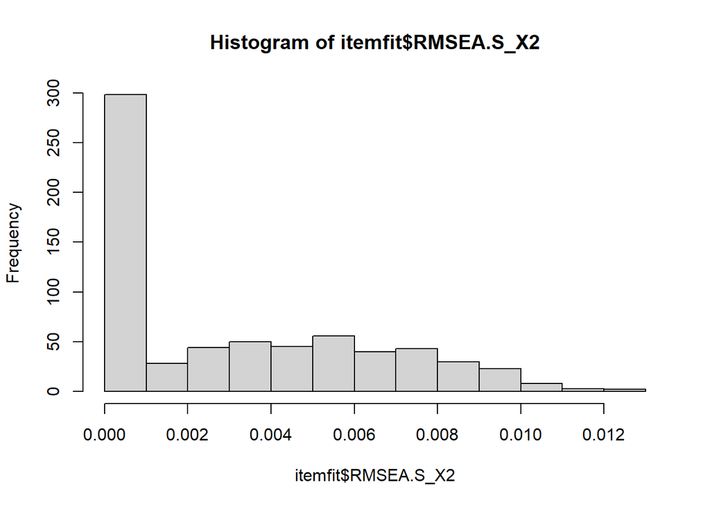

```r
hist(itemfit$RMSEA.S_X2)
```

Let’s take items with RMSEA < 0.001:

```r
nrow(itemfit[itemfit$RMSEA.S_X2 < 0.001, ])
```

```
## [1] 298
```

```r
mod_restr3 <- mirt(data = responses[, itemfit[itemfit$RMSEA.S_X2 < 0.001, "item"]], model = 1, SE = TRUE)
```

```r
mod_restr3
```

```
##
## Call:
## mirt(data = responses[, itemfit[itemfit$RMSEA.S_X2 < 0.001, "item"]],
##     model = 1, SE = TRUE)
##
## Full-information item factor analysis with 1 factor(s).
## Converged within 1e-04 tolerance after 243 EM iterations.
## mirt version: 1.34
## M-step optimizer: BFGS
## EM acceleration: Ramsay
## Number of rectangular quadrature: 61
## Latent density type: Gaussian
##
## Information matrix estimated with method: Oakes
## Second-order test: model is a possible local maximum
## Condition number of information matrix =  133.3972
##
## Log-likelihood = -206612.8
## Estimated parameters: 596
## AIC = 414417.6; AICc = 414836.2
## BIC = 417838.2; SABIC = 415944.6
## G2 (9999999404) = 378406.4, p = 1
## RMSEA = 0, CFI = NaN, TLI = NaN
```

```r
mod_restr4 <- mirt(data = responses[, itemfit[itemfit$RMSEA.S_X2 < 0.001, "item"]], model = 1, SE = TRUE, quadpts = 101)
```

```r
mod_restr4
```

```
##
## Call:
## mirt(data = responses[, itemfit[itemfit$RMSEA.S_X2 < 0.001, "item"]],
##     model = 1, SE = TRUE, quadpts = 101)
##
## Full-information item factor analysis with 1 factor(s).
## Converged within 1e-04 tolerance after 453 EM iterations.
## mirt version: 1.34
## M-step optimizer: BFGS
## EM acceleration: Ramsay
## Number of rectangular quadrature: 101
## Latent density type: Gaussian
##
## Information matrix estimated with method: Oakes
## Second-order test: model is a possible local maximum
## Condition number of information matrix =  279.8034
##
## Log-likelihood = -206416.2
## Estimated parameters: 596
## AIC = 414024.4; AICc = 414443
## BIC = 417445.1; SABIC = 415551.5
## G2 (9999999404) = 378013.3, p = 1
## RMSEA = 0, CFI = NaN, TLI = NaN
```

```r
mod_restr5 <- mirt(data = responses[, itemfit[itemfit$RMSEA.S_X2 < 0.001, "item"]], model = 1, SE = TRUE, quadpts = 151, technical=list(NCYCLES=3000))
```

```r
mod_restr5
```

```
##
## Call:
## mirt(data = responses[, itemfit[itemfit$RMSEA.S_X2 < 0.001, "item"]],
##     model = 1, SE = TRUE, quadpts = 151, technical = list(NCYCLES = 3000))
##
## Full-information item factor analysis with 1 factor(s).
## Converged within 1e-04 tolerance after 1531 EM iterations.
## mirt version: 1.34
## M-step optimizer: BFGS
## EM acceleration: Ramsay
## Number of rectangular quadrature: 151
## Latent density type: Gaussian
##
## Information matrix estimated with method: Oakes
## Second-order test: model is a possible local maximum
## Condition number of information matrix =  811.3508
##
## Log-likelihood = -206405.1
## Estimated parameters: 596
## AIC = 414002.1; AICc = 414420.7
## BIC = 417422.8; SABIC = 415529.2
## G2 (9999999404) = 377991, p = 1
## RMSEA = 0, CFI = NaN, TLI = NaN
```

```r
mod_restr6 <- mirt(data = responses[, itemfit[itemfit$RMSEA.S_X2 < 0.001, "item"]], model = 1, SE = TRUE, quadpts = 301, technical=list(NCYCLES=5000))
```

```r
mod_restr6
```

```
##
## Call:
## mirt(data = responses[, itemfit[itemfit$RMSEA.S_X2 < 0.001, "item"]],
##     model = 1, SE = TRUE, quadpts = 301, technical = list(NCYCLES = 5000))
##
## Full-information item factor analysis with 1 factor(s).
## Converged within 1e-04 tolerance after 981 EM iterations.
## mirt version: 1.34
## M-step optimizer: BFGS
## EM acceleration: Ramsay
## Number of rectangular quadrature: 301
## Latent density type: Gaussian
##
## Information matrix estimated with method: Oakes
## Second-order test: model is a possible local maximum
## Condition number of information matrix =  955.0375
##
## Log-likelihood = -206404.8
## Estimated parameters: 596
## AIC = 414001.7; AICc = 414420.3
## BIC = 417422.3; SABIC = 415528.7
## G2 (9999999404) = 377990.5, p = 1
## RMSEA = 0, CFI = NaN, TLI = NaN
```

## Simulation with Kachergis setting (298 items)

```r
fscores_r2 <- fscores(mod_restr6, method = "MAP")
params_r2 <- as.data.frame(coef(mod_restr6, simplify = TRUE)$items)[1:2]
mo_r2 <- generate.mirt_object(params_r2, '2PL')
cl <- makeCluster(detectCores())
sim_results_k_r2 <- mirtCAT(mo = mo_r2, method = "MAP", criteria = "MI", start_item = "MI", local_pattern = responses[, itemfit[itemfit$RMSEA.S_X2 < 0.001, "item"]], cl = cl, design = list(min_SEM = 0.15, min_items = 25, max_items = 50))
```

#### Correlation

```r
sim_results <- sim_results_k_r2
thetas <- laply(sim_results, function(x) x$thetas)
cor(thetas, as.numeric(fscores_r2))
```

```
## [1] 0.9882318
```

In full pool it was 0.9820521

#### Average SE

```r
SEthetas <- laply(sim_results, function(x) x$SE_thetas)
round(mean(SEthetas),3)
```

```
## [1] 0.132
```

In full pool it was 0.121.

#### Mean number of items

```r
items_answered <- laply(sim_results, function(x) length(x$items_answered))
round(mean(items_answered), 1)
```

```
## [1] 30.8
```

In full pool it was 29.6.

#### Unused items

```r
#Prepare df with frequencies of usage of items
frequency_df <- data.frame(number.ws = c(1:nrow(params_r2)), freq = rep(0, nrow(params_r2)))

#Update df with number of occurence of given item
for (p in 1:length(sim_results)){
  items <- sim_results[[p]]$items_answered
  for (number.ws in items){
    frequency_df[frequency_df["number.ws"] == number.ws, "freq"] <- frequency_df[frequency_df["number.ws"] == number.ws, "freq"] + 1
  }
}

length(which(frequency_df$freq == 0))
```

```
## [1] 117
```

In full pool it was 430